# Interactions Homework

## Replicated Regression and Interaction Effects

Loading the data from kelp

```r
library(tidyverse)
```

```r
library(ggplot2)
library(performance)
library(modelr)
library(visdat)
library(skimr)
library(GGally)
library(car)
library(broom)
library(visreg)
library(emmeans)
# Load the data
kelp <- read.csv('https://biol607.github.io/lab/data/kelp_pred_div_byrnesetal2006.csv')

kelp <- kelp|>
  filter(!is.na(Predator_Diversity))|>
  mutate(Trial = as.factor(Trial),
         Predator_Diversity = as.numeric(Predator_Diversity))

# Fit a model with an interaction/continuous
kelp_lm_c <- lm(Porp_Change ~ Predator_Diversity * Trial, data = kelp)
tidy(kelp_lm_c)
```

```
## # A tibble: 6 × 5
##   term                      estimate std.error statistic    p.value
##   <chr>                        <dbl>     <dbl>     <dbl>      <dbl>
## 1 (Intercept)               -0.564      0.112    -5.05   0.00000955
## 2 Predator_Diversity         0.182      0.0666    2.73   0.00928
## 3 Trial2                    -0.0554     0.159    -0.348  0.730
## 4 Trial3                     0.606      0.158     3.84   0.000422
## 5 Predator_Diversity:Trial2  0.00362    0.0991    0.0365 0.971
## 6 Predator_Diversity:Trial3 -0.132      0.0942   -1.40   0.169
```

```r
r2(kelp_lm_c)
```

```
## # R2 for Linear Regression
##        R2: 0.522
##   adj. R2: 0.464
```

```r
# discrete
kelp_d <- kelp|>
  mutate(Predator_Diversity = as.factor(Predator_Diversity))
kelp_lm_d <- lm(Porp_Change ~ Predator_Diversity * Trial, data = kelp_d)
tidy(kelp_lm_d)
```

```
## # A tibble: 9 × 5
##   term                       estimate std.error statistic  p.value
##   <chr>                         <dbl>     <dbl>     <dbl>    <dbl>
## 1 (Intercept)                 -0.632      0.157    -4.03  0.000260
## 2 Predator_Diversity1          0.283      0.181     1.56  0.127
## 3 Predator_Diversity3          0.588      0.207     2.83  0.00732
## 4 Trial2                      -0.215      0.222    -0.971 0.338
## 5 Trial3                       0.595      0.222     2.68  0.0108
## 6 Predator_Diversity1:Trial2   0.243      0.256     0.950 0.348
## 7 Predator_Diversity3:Trial2   0.0824     0.304     0.271 0.788
## 8 Predator_Diversity1:Trial3  -0.114      0.256    -0.447 0.658
## 9 Predator_Diversity3:Trial3  -0.388      0.293    -1.32  0.193
```

```r
r2(kelp_lm_d)
```

```
## # R2 for Linear Regression
##        R2: 0.578
##   adj. R2: 0.489
```

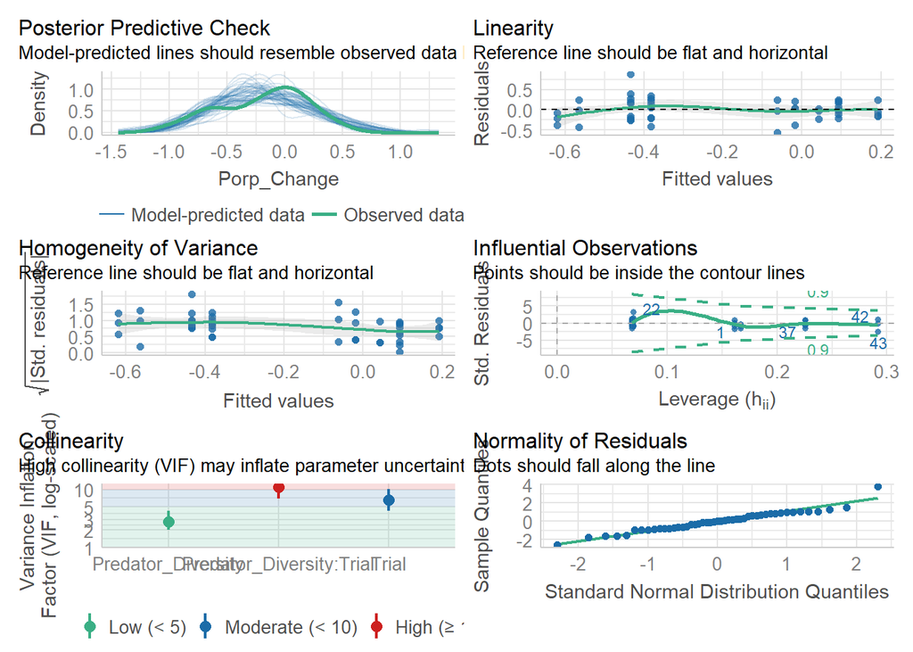

```r
# Test Asssumptions and modify model if needed
check_model(kelp_lm_c)
```

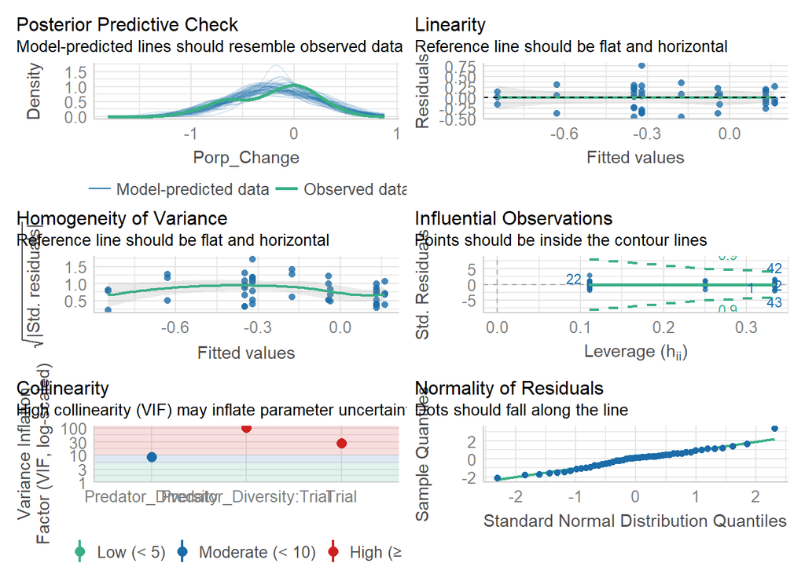

```r
check_model(kelp_lm_d)
```

```r
# Evaluate results

# Visualize results
```

It appears as if the continuous is the best at meeting assumptions as the discrete model has some wonky HOV and collinearity as well, there also is variation in the data in the linearity assumption plot so, I will stick with the continuous version.

Comparing the results with both models: Discrete/Continuous

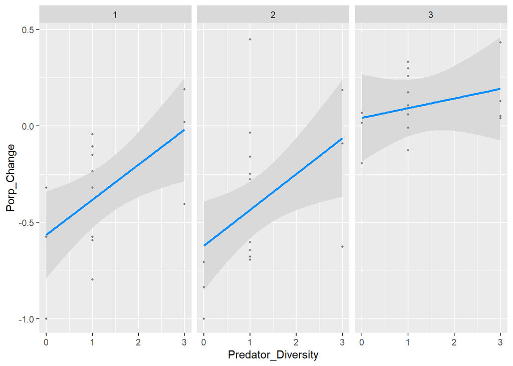

```r
# Continuous Comparison
visreg(kelp_lm_c, "Predator_Diversity", "Trial", gg=T)
```

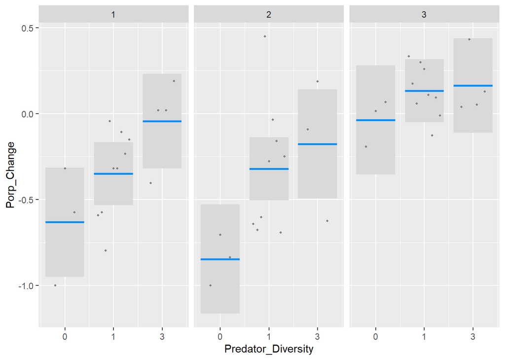

```r
visreg(kelp_lm_d, "Predator_Diversity", "Trial", gg=T)
```

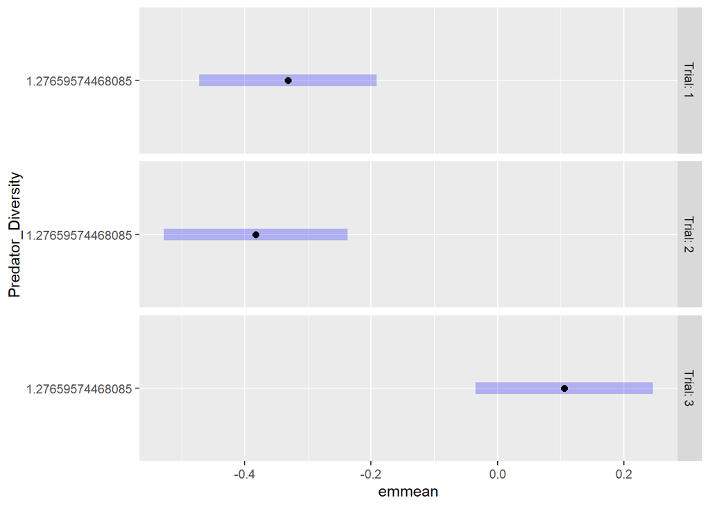

```r
# These are showing us that there could be no interaction between these two predictors

kelp_em_c <- emmeans(kelp_lm_c, specs = ~ Predator_Diversity|Trial)
kelp_em_c |> plot()
```

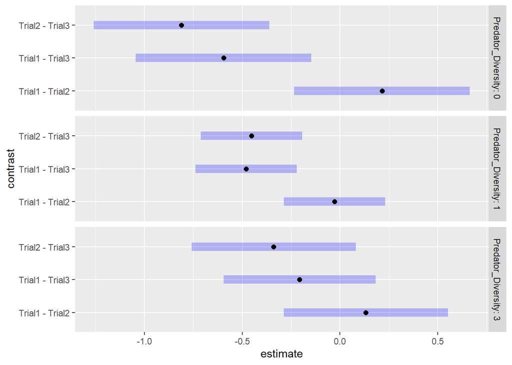

```r
# Discrete Comparison
kelp_em_d <- emmeans(kelp_lm_d, specs = ~ Trial | Predator_Diversity)|>
  contrast(method = "pairwise")|>
  confint(adjust = "none")|>
  plot()
kelp_em_d
```

```r
emtrends(kelp_lm_c, ~ Trial, var = "Predator_Diversity")
```

```
##  Trial Predator_Diversity.trend     SE df lower.CL upper.CL
##  1                        0.182 0.0666 41   0.0474    0.317
##  2                        0.186 0.0733 41   0.0375    0.334
##  3                        0.050 0.0666 41  -0.0846    0.185
##
## Confidence level used: 0.95
```

```r
# Refitting the model to have no interaction
kelp_lm_no <- lm(Porp_Change ~ Predator_Diversity + Trial, data = kelp)
tidy(kelp_lm_no)
```

```
## # A tibble: 4 × 5
##   term               estimate std.error statistic     p.value
##   <chr>                 <dbl>     <dbl>     <dbl>       <dbl>
## 1 (Intercept)         -0.505     0.0875    -5.77  0.000000796
## 2 Predator_Diversity   0.136     0.0399     3.42  0.00140
## 3 Trial2              -0.0562    0.101     -0.558 0.580
## 4 Trial3               0.433     0.0991     4.37  0.0000762
```

```r
r2(kelp_lm_no)
```

```
## # R2 for Linear Regression
##        R2: 0.492
##   adj. R2: 0.456
```

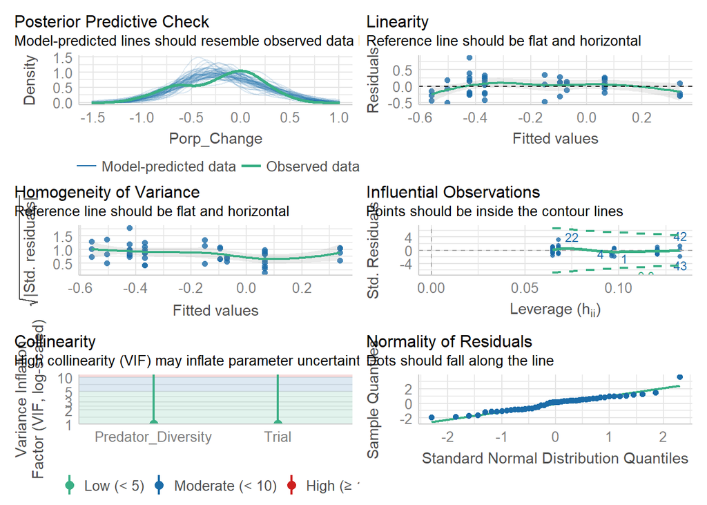

```r
check_model(kelp_lm_no)
```

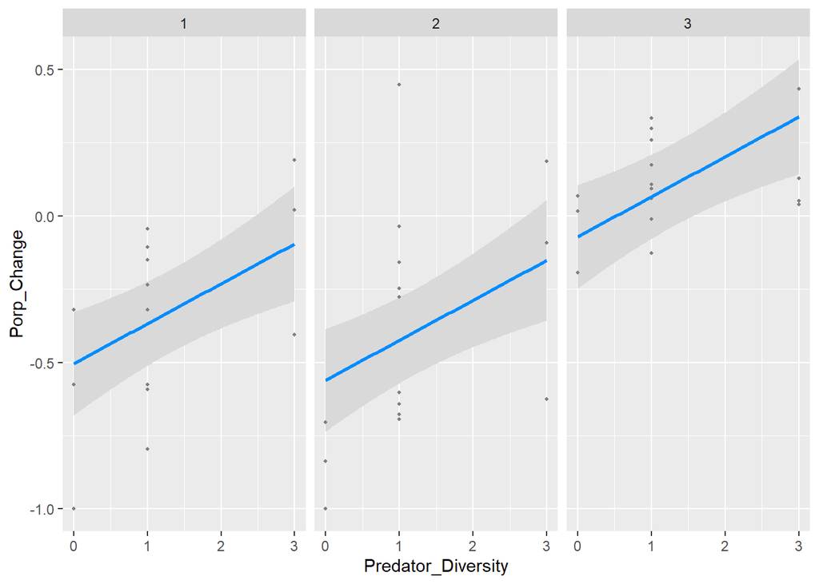

```r
visreg(kelp_lm_no, "Predator_Diversity", "Trial", gg=T)
```

It appears as though proportional change of kelp is changing along with predator_Diversity in a positive manner. In other words, when there is a greater diversity of predators, then herbivores are being eaten and kelp is allowed to grow indicated by the positive slope of the model. This is true regardless of trial since there is no interaction effect detected.

## Interaction with Continuous Variables

```r
sims <- read_csv('https://biol607.github.io/homework/data/c_burial_sims.csv')
str(sims)
```

```
## spec_tbl_df [100 × 4] (S3: spec_tbl_df/tbl_df/tbl/data.frame)
##  $ sink_rate               : num [1:100] 0.617 3.888 3.327 0.402 2.376 ...
##  $ microbial_abundance     : num [1:100] 3.427 0.119 0.38 0 0.422 ...
##  $ detritivore_biomass     : num [1:100] 3.21 3.69 2.56 3.77 1.5 ...
##  $ net_carbon_sequestration: num [1:100] 5.929 7.251 0.424 -6.09 -0.182 ...
##  - attr(*, "spec")=
##   .. cols(
##   ..   sink_rate = col_double(),
##   ..   microbial_abundance = col_double(),
##   ..   detritivore_biomass = col_double(),
##   ..   net_carbon_sequestration = col_double()
##   .. )
##  - attr(*, "problems")=<externalptr>
```

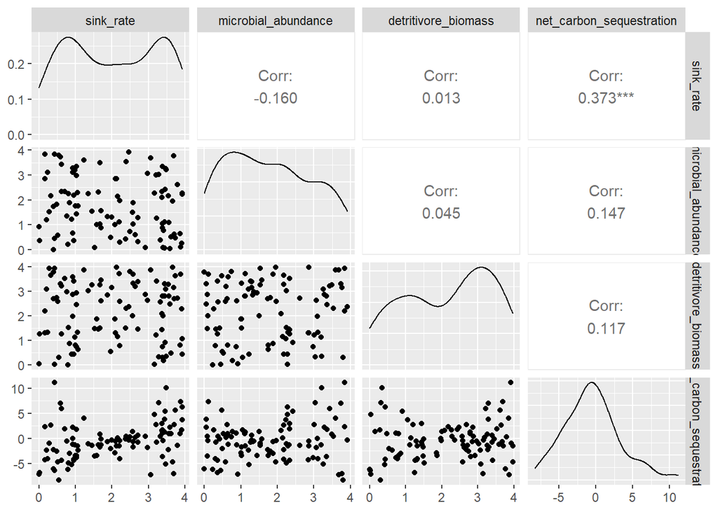

```r
ggpairs(sims)
```

```r
#model
sims_lm <- lm(net_carbon_sequestration ~ sink_rate * microbial_abundance * detritivore_biomass, data = sims)
tidy(sims_lm)
```

```
## # A tibble: 8 × 5
##   term                                          estim…¹ std.e…² stati…³  p.value
##   <chr>                                           <dbl>   <dbl>   <dbl>    <dbl>
## 1 (Intercept)                                    -5.98   0.594   -10.1  1.69e-16
## 2 sink_rate                                       0.897  0.262     3.43 9.07e- 4
## 3 microbial_abundance                            -1.79   0.290    -6.18 1.76e- 8
## 4 detritivore_biomass                            -0.724  0.240    -3.02 3.26e- 3
## 5 sink_rate:microbial_abundance                   1.73   0.130    13.3  3.82e-23
## 6 sink_rate:detritivore_biomass                   0.818  0.103     7.98 4.04e-12
## 7 microbial_abundance:detritivore_biomass         1.97   0.113    17.5  6.09e-31
## 8 sink_rate:microbial_abundance:detritivore_bi…  -1.20   0.0504  -23.9  3.14e-41
## # … with abbreviated variable names ¹estimate, ²std.error, ³statistic
```

```r
r2(sims_lm)
```

```
## # R2 for Linear Regression
##        R2: 0.946
##   adj. R2: 0.942
```

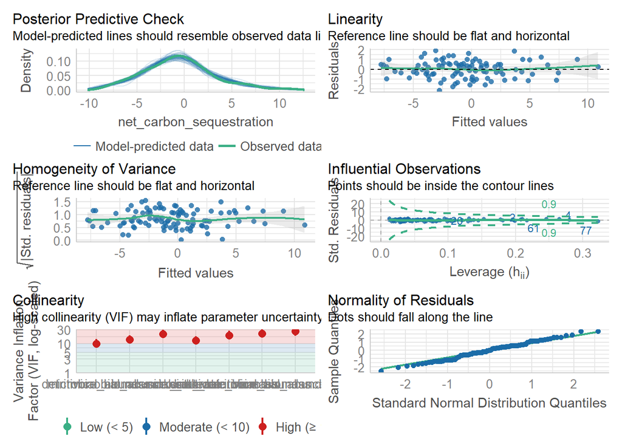

```r
check_model(sims_lm)
```

Model looks nice!

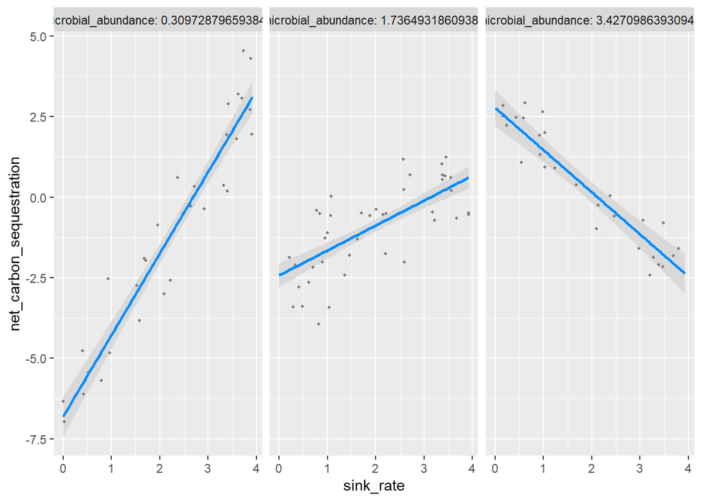

```r
visreg(sims_lm, "sink_rate", "microbial_abundance", gg = TRUE)
```

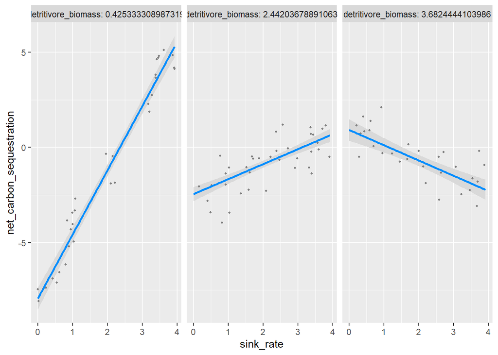

```r
visreg(sims_lm, "sink_rate", "detritivore_biomass", gg = TRUE)
```

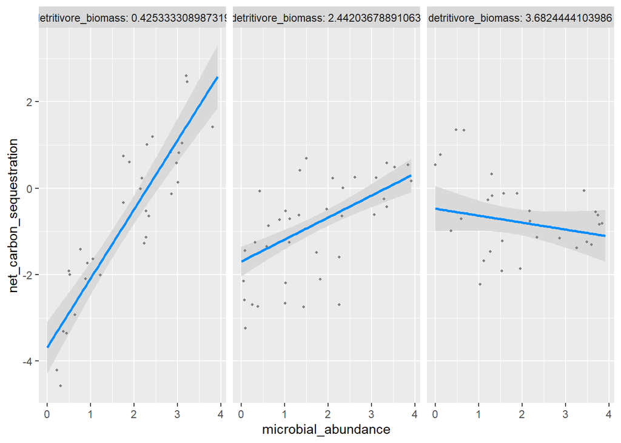

```r
visreg(sims_lm, "microbial_abundance", "detritivore_biomass", gg = TRUE)
```

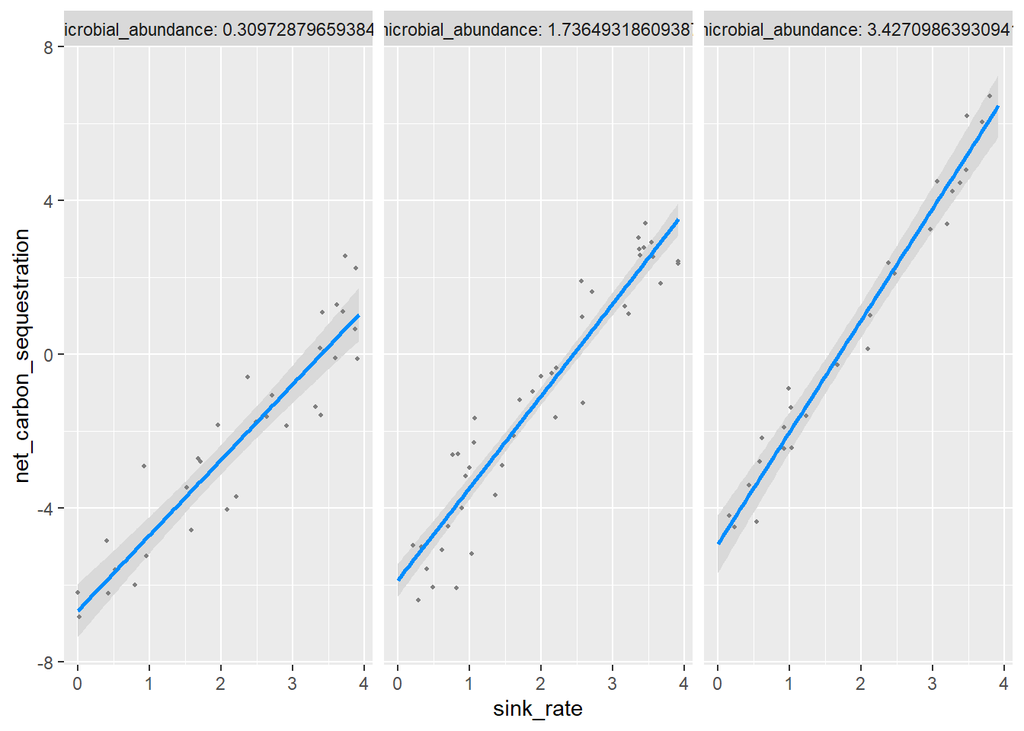

```r
visreg(sims_lm, "sink_rate", "microbial_abundance", cond = list(detritivore_biomass = 1.187), gg = T)
```

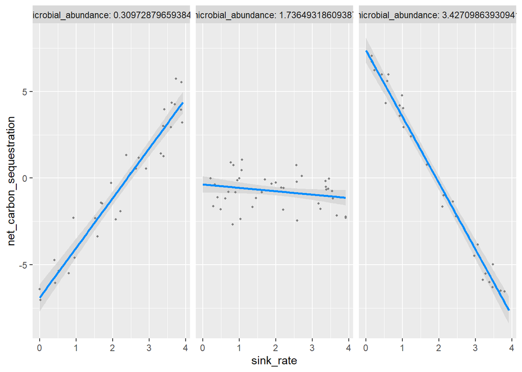

```r
visreg(sims_lm, "sink_rate", "microbial_abundance", cond = list(detritivore_biomass = 3.224), gg = T)
```

Meta 1: Interaction effects are interesting because it attempts to explain a phenomenon of nature in a more complex way which is often the case with nature. It can show you the change in something when something else is affecting that change. It can get scary when there are more than 2 predictors.

Meta 2: In my research there are many interaction effects that could play a role. For example I can give a treatment to cells or rats and there could be an interaction whether the cells or the rat sex is male or female.

Meta 3: I have a hard time understanding how to model the mean slopes in the linear models. My problems are more on the side of coding rather than the theory side.

Meta 4: This took me roughly 3 hours to complete with a partner.

Meta 5: I would say I am sufficient on this assignment because I can’t quite evaluate the models that well, like I am uncomfortable when the question on the homework is asking whether the model fits well or if there is an interaction or what the coefficients mean when there are interaction effects or more than 3 predictors for interaction effects. It still seems like a subjective method rather than objective (p-values). Old habits die hard I guess.

Also hard for me to determine if there is a true difference in means rather than something that could or could not be a difference.